# healthy_relationships

Kevin Gilds, MPA

May 28, 2016

`

## Healthy Relationship Outcome

Relationship skills are a critical component of success in all realms of life. The Healthy Relationship questions measures the behaviors and attitudes of the respondent regarding their relationship skills. Questions that measure healthy relationships skills include the following:

*Healthy Relationship Questions*

1. If I have a serious problem, I have people to talk with.
2. I let people know if they have hurt my feelings.
3. I let my friends know when I think they are good at something.
4. In any relationship - romantic or not - I make it clear when I don’t feel comfortable.

The number of pre and post survey that could be matched is **74**, and the percent of students with a successful outcome is **82.43%**

1. The number of students who achieved at a high level is **53**:
2. The number of studens who did not achieve at high level but increased outcome socre **8**:

The improvement in outcome scores is graphically represented below.

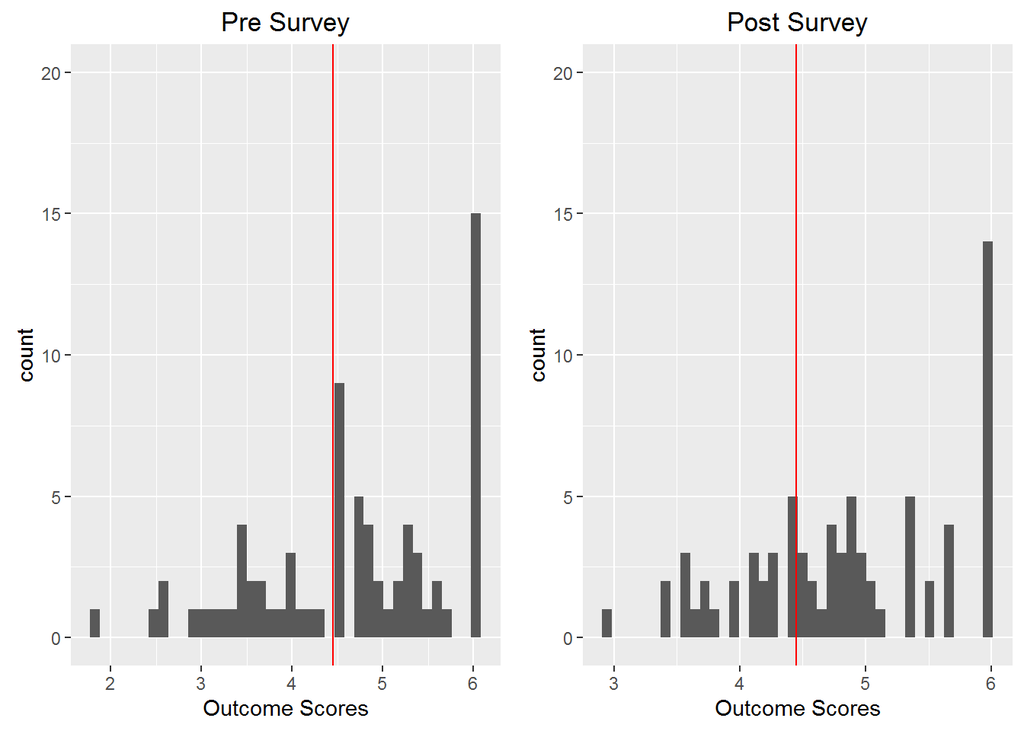

The percent of students who achieved the healthy releationship at a high level is **71.62%**. The imrovement is represented graphically below.

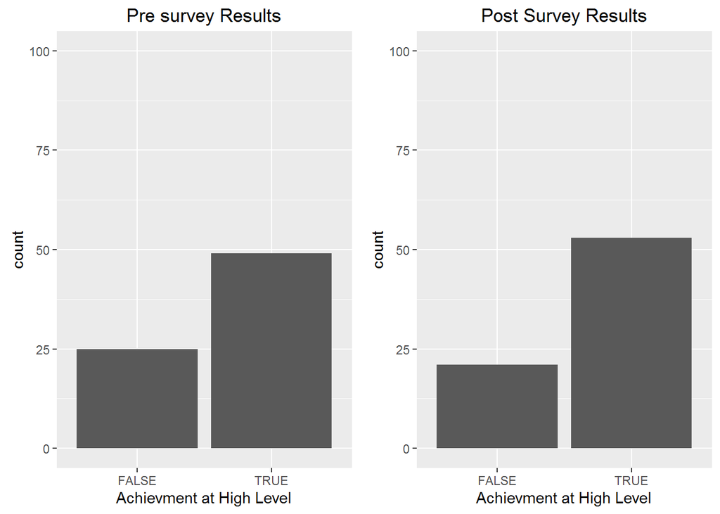

The percent of students who went from low achievment to high achievement **21.62%**. The number of students who had the opportunity to improve their healthy relationship outcome score is **53**, and the mean increase in outcome score is **0.2915094**

The increase in the healthy relationship outcome scores is represented graphically below. Marks to the right of the veticial red line represents an increase in the outcome score. Marks above the horizintal line represents scores above the high and low achievement.

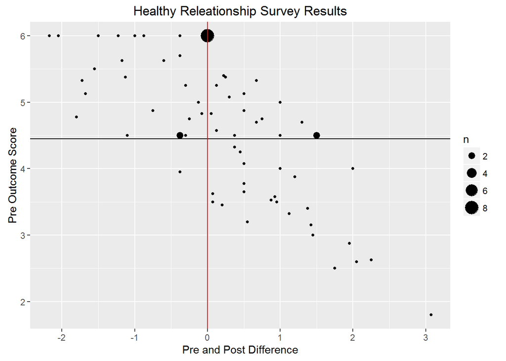